# Resumen del módulo de Manejo de Software

Programa Internacional de Estadística Aplicada a la Investigación Científica

Linda Cabrera

2022-10-20

# 1 Profesoras

Gabriela Castro Centeno y Linda Cabrera Orellana son las profesoras que impartieron el módulo.

## 1.1 Gabriela Castro

### 1.1.1 Sociedad Ecuatoriana de Estadística

#### 1.1.1.1 Directora Ejecutiva

## 1.2 Linda Cabrera

### 1.2.1 R-Ladies Guayaquil

#### 1.2.1.1 Co-organizadora

# 2 Contenido del módulo

El módulo inició el lunes 3 de octubre de 2022 y finalizará el jueves 20 de octubre de 2022, abarcó los siguientes temas:

1. Introducción a R
2. Introducción a R Commander
3. Introducción a SPSS
4. RStudio
   1. Introducción a RStudio
   2. Importación y orden de los datos en R
   3. Manipulación de datos en R
   4. Análisis exploratorio de datos
   5. Comunicando resultados con R

El módulo tiene una duración de 25 horas y en cada capítulo de Rstudio se profundizaron temas relevantes para el contenido del Programa Internacional de Estadística Aplicada a la Investigación Científica. Por ejemplo en el capítulo de Importación y orden de los datos en R se revisaron los siguientes temas:

- Calidad de los datos
- Importar datos
  - Importar archivos `.csv`
  - Importar desde Excel
  - Importar desde SPSS y STATA
- Estructuras de datos
  - Vectores
  - Data.frames (Tibbles)
  - Funciones básicas
- Tipos de datos
  - Numéricos
  - Cadena de caracteres
  - Factores
  - Fechas y Horas

Horario del módulo:

[output not shown]

# 3 RStudio

En la introducción de la parte de RStudio recordamos una frase de Hadley Wickhman para recordar que aprender R es aprender un nuevo idioma por lo que necesita práctica y paciencia:

> “Cuando comienzas a programar, es fácil sentirte realmente frustrado… Es solo una parte natural de la programación, le sucede a todos y se vuelve cada vez menos con el tiempo. No te culpes. Solo tómate un descanso, haz algo divertido y luego regresa e inténtalo de nuevo más tarde.”

## 3.1 Introducción a RStudio

1. Descargamos RStudio en el siguiente [link](https://www.rstudio.com/products/rstudio/download/)
2. Instalamos RStudio en nuestras computadoras
3. Conocimos el entorno de RStudio
4. Aprendimos a instalar y cargar paquetes
5. Es posible usar R como una calculadora, donde podemos hacer operaciones desde muy sencillas a muy complicadas. Por ejemplo puedo calcular sin problema:
   $$\sqrt{23^3+10}-\dfrac{2}{3}+ \ln(1) -
   e^3$$
6. Aprendimos a crear objetos mediante asignaciones <- cuyo atajo de teclado es Alt+-.
7. Aprendimos qué es una función en R y que nos ahorran cálculos en nuestro análisis. R tiene funciones para casi todo lo que deseemos hacer en nuestros trabajos. Por ejemplo, para calcular la integral de una función puedo utilizar la función integrate(), en lugar de hacer el cálculo matemático paso a paso. Vamos a realizar el cálculo de una integral definida de forma analítica y a través de R:

**Ejercicio:** Calcular ${\displaystyle \int_{1}^{3} (x^2 + 4) \, dx}$ Recordemos el *Teorema Fundamental del Cálculo*:

**Teorema**

Sea ${\displaystyle f}$ una función integrable en el intervalo ${\displaystyle [a,b]}$ y ${\displaystyle f=g'}$ para alguna función ${\displaystyle g}$ entonces:
$${\displaystyle \int_{a}^{b} f(x) \, dx =
g(b) - g(a)}$$

Resolvemos la integral definida:
$$\left.\begin{array}{lcl}
{\displaystyle \int_{1}^{3} (x^2 + 4) \, dx} & = & \left|
\dfrac{x^3}{3} + 4x \right|_{1}^{3}\\
& = & \left( \dfrac{3^3}{3} + 4(3) \right) - \left(
\dfrac{1^3}{3} + 4(1) \right)\\
& = & 9 + 12 - \frac{1}{3} - 4\\
& = & 17 - \frac{1}{3} = \frac{50}{3} = 16.67
\end{array}\right.$$

Ahora utilizamos la función `integrate()` en R para calcular la misma integral. Si consultamos `?integrate` en la consola podemos observar que necesitamos 3 argumentos que son la función function(x), el límite inferior lower y el límite superior upper: `integrate(function(x) (x^2 + 4), lower =1, upper = 3)`

El material de este capítulo se encuentra en [Introducción a RStudio](https://lindajzmin.github.io/r-research/intro_rstudio.html)

## 3.2 Importación y orden de los datos en R

El material de este capítulo se encuentra en [Importación y Orden de los Datos en R](https://lindajzmin.github.io/r-research/datos_en_r.html)

## 3.3 Manipulación de datos en R

Este capítulo nos da una introducción práctica a los datos ordenados (o tidy data) y a las herramientas que provee el paquete `tidyr`, puedes leer más en *R para Ciencia de Datos* de Wickham & Grolemund (2017). Si deseas aprender más acerca de la teoría subyacente, puede que te guste el artículo Tidy Data de Wickham (2014) publicado en la revista Journal of Statistical Software, http://www.jstatsoft.org/v59/i10/paper.

```r
profesores <- read_excel("Datos_R/r_profesores.xlsx")
```

Hicimos esta tablita:

Tabla 1. Resumen de indicadores

| Nivel que imparte docencia | Profesores | Estudiantes | Estudiantes Promedio | Edad Promedio |
| --- | --- | --- | --- | --- |
| Educación infantil, primaria o básica | 98 | 3148 | 32 | 36 |
| Educación secundaria y bachillerato | 42 | 1398 | 33 | 42 |
| Educación superior | 35 | 1138 | 33 | 36 |

Usamos este código:

```r
profesores %>%
    group_by(Nivel_docencia) %>%
    summarise(Profesores = n(),
              Estudiantes = sum(No_Alumnos),
              'Estudiantes Promedio' = round(Estudiantes/Profesores),
              'Edad Promedio' = round(mean(Edad)))%>%
    rename("Nivel que imparte docencia"=Nivel_docencia)
```

Se hace un gráfico con el paquete “Datos”:

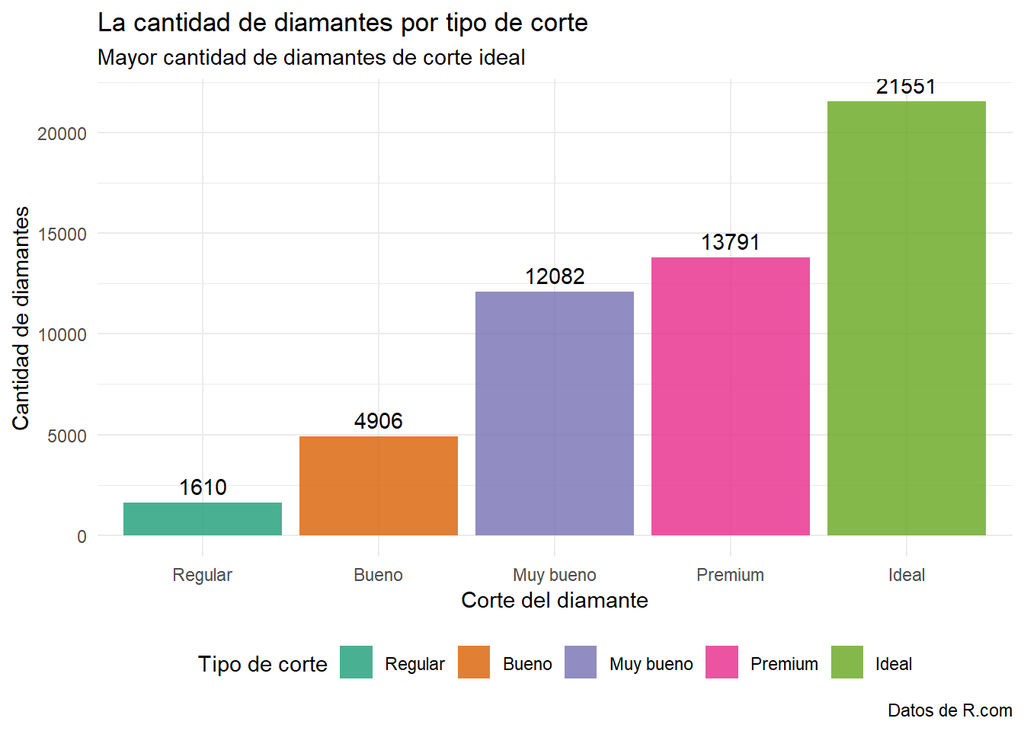

El mismo gráfico pero solo el código:

```r
diamantes %>% ggplot(aes(x = corte,
                         fill=corte)) +
    geom_bar(alpha=0.8) +
    scale_fill_brewer(palette = "Dark2") +
    geom_text(aes(label=..count..),
              stat = 'count',
              vjust=-0.5) +
    theme_minimal() +
    theme(legend.position = "bottom") +
    labs(x = "Corte del diamante",
         y = "Cantidad de diamantes",
         title = "La cantidad de diamantes por tipo de corte",
         subtitle = "Mayor cantidad de diamantes de corte ideal",
         caption = "Datos de R.com",
         fill = "Tipo de corte")
```

# Referencias

Wickham, H. (2014). Tidy data. *Journal of Statistical Software*, *59*(10), 1–23. https://doi.org/10.18637/jss.v059.i10

Wickham, H., & Grolemund, G. (2017). *R for data science (2e)*. O’Reilly.